# Lab week 1 - Tree-based methods

Data Science and Machine Learning 3 - CEU 2019

Jeno Pal

2019-02-18

```r
library(data.table)
```

```r
library(caret)
library(rpart)
library(rpart.plot)
library(xgboost)
library(randomForest)
library(gbm)
library(ISLR)
library(skimr)
```

## Bagging, random forests

We covered decision trees in previous classes. Using it as a base model lets us build many different models with less variance and better predictive power. The downside: interpretation gets harder.

Idea: as individual trees are unstable and have high variance, train many versions on bootstrap samples (“Bagging”: Bootstrap AGGregation). Then predict: take the average (regression), majority vote / class share (classification).

Random forests: randomly constrain the set of predictor variables used to grow trees (randomly select at each split). Goal: avoid correlated trees that are very similar to each other, still with the aim of decreasing variance.

```r
data(Hitters)
data <- data.table(Hitters)
skim(data)
```

|  | variable | type | stat | level | value | formatted |
| --- | --- | --- | --- | --- | --- | --- |
| 1 | AtBat | integer | missing | .all | 0.000000 | 0 |
| 2 | AtBat | integer | complete | .all | 322.000000 | 322 |
| 3 | AtBat | integer | n | .all | 322.000000 | 322 |
| 4 | AtBat | integer | mean | .all | 380.928571 | 380.93 |
| 5 | AtBat | integer | sd | .all | 153.404981 | 153.4 |
| 6 | AtBat | integer | p0 | .all | 16.000000 | 16 |
| 7 | AtBat | integer | p25 | .all | 255.250000 | 255.25 |
| 8 | AtBat | integer | p50 | .all | 379.500000 | 379.5 |
| 9 | AtBat | integer | p75 | .all | 512.000000 | 512 |
| 10 | AtBat | integer | p100 | .all | 687.000000 | 687 |

[output cut: 201 more lines]

```r
# goal: predict log salary
data <- data[!is.na(Salary)]
data[, log_salary := log(Salary)]
data[, Salary := NULL]
```

```r
training_ratio <- 0.75
set.seed(1234)
train_indices <- createDataPartition(
  y = data[["log_salary"]],
  times = 1,
  p = training_ratio,
  list = FALSE
)

data_train <- data[train_indices, ]
data_test <- data[-train_indices, ]
```

Let’s see benchmarks: a linear model and a simple regression tree.

```r
train_control <- trainControl(
  method = "repeatedcv",
  number = 5,
  repeats = 3
)

set.seed(857)
linear_model <- train(log_salary ~ .,
                      method = "lm",
                      data = data_train,
                      trControl = train_control)
linear_model
```

```
## Linear Regression
##
## 200 samples
##  19 predictor
##
## No pre-processing
## Resampling: Cross-Validated (5 fold, repeated 3 times)
## Summary of sample sizes: 160, 160, 160, 159, 161, 162, ...
## Resampling results:
##
##   RMSE       Rsquared   MAE
##   0.7039273  0.4071298  0.5665639
##
## Tuning parameter 'intercept' was held constant at a value of TRUE
```

```r
set.seed(857)
simple_tree_model <- train(log_salary ~ .,
                      method = "rpart",
                      data = data_train,
                      tuneGrid = data.frame(cp = c(0.01, 0.02, 0.05)),
                      trControl = train_control)
simple_tree_model
```

```
## CART
##
## 200 samples
##  19 predictor
##
## No pre-processing
## Resampling: Cross-Validated (5 fold, repeated 3 times)
## Summary of sample sizes: 160, 160, 160, 159, 161, 162, ...
## Resampling results across tuning parameters:
##
##   cp    RMSE       Rsquared   MAE
##   0.01  0.5553964  0.6201776  0.4124635
##   0.02  0.5387555  0.6405251  0.4009572
##   0.05  0.5966238  0.5666164  0.4474878
##
## RMSE was used to select the optimal model using the smallest value.
## The final value used for the model was cp = 0.02.
```

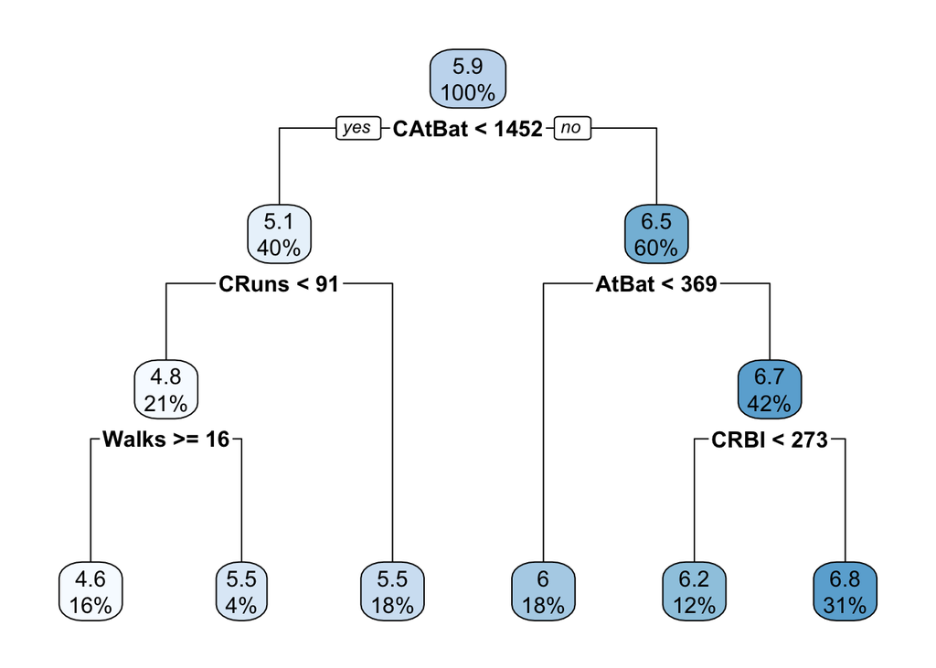

```r
rpart.plot(simple_tree_model[["finalModel"]])
```

For random forests, `mtry` sets the number of variables randomly chosen for any split in the tree. When `mtry` equals the number of features, it is the bagging.

```r
tune_grid <- expand.grid(
  .mtry = c(2, 3, 5, 7, 9, 12, 19),
  .splitrule = "variance",
  .min.node.size = c(5, 10)
)

# random forest
set.seed(857)
rf_model <- train(log_salary ~ .,
                  method = "ranger",
                  data = data_train,
                  trControl = train_control,
                  tuneGrid = tune_grid,
                  importance = "impurity"
                  )
rf_model
```

```
## Random Forest
##
## 200 samples
##  19 predictor
##
## No pre-processing
## Resampling: Cross-Validated (5 fold, repeated 3 times)
## Summary of sample sizes: 160, 160, 160, 159, 161, 162, ...
## Resampling results across tuning parameters:
##
##   mtry  min.node.size  RMSE       Rsquared   MAE
##    2     5             0.4588081  0.7396438  0.3280732
##    2    10             0.4608499  0.7384388  0.3314981
##    3     5             0.4541393  0.7433037  0.3246432
##    3    10             0.4573197  0.7386151  0.3265915
##    5     5             0.4587539  0.7372282  0.3289116
##    5    10             0.4597372  0.7360343  0.3284158
##    7     5             0.4623923  0.7338362  0.3304631
##    7    10             0.4631014  0.7315707  0.3314311
##    9     5             0.4663844  0.7288490  0.3352086
##    9    10             0.4670338  0.7280564  0.3350672
##   12     5             0.4717894  0.7235606  0.3383836
##   12    10             0.4697842  0.7257355  0.3381579
##   19     5             0.4774257  0.7160146  0.3449372
##   19    10             0.4764853  0.7179844  0.3421175
##
## Tuning parameter 'splitrule' was held constant at a value of variance
## RMSE was used to select the optimal model using the smallest value.
## The final values used for the model were mtry = 3, splitrule =
##  variance and min.node.size = 5.
```

```r
tune_grid <- expand.grid(
  .mtry = c(2, 3, 5),
  .splitrule = "variance",
  .min.node.size = 5
)

# the number of trees is not a tuning parameter with caret
# default is 500, you can change it with passing the parameter to train
set.seed(857)
rf_model_ntree_10 <- train(log_salary ~ .,
                  method = "ranger",
                  data = data_train,
                  trControl = train_control,
                  tuneGrid = tune_grid,
                  num.trees = 10,
                  importance = "impurity"
                  )
rf_model_ntree_10
```

```
## Random Forest
##
## 200 samples
##  19 predictor
##
## No pre-processing
## Resampling: Cross-Validated (5 fold, repeated 3 times)
## Summary of sample sizes: 160, 160, 160, 159, 161, 162, ...
## Resampling results across tuning parameters:
##
##   mtry  RMSE       Rsquared   MAE
##   2     0.4868558  0.7016910  0.3548941
##   3     0.4827408  0.7085551  0.3468780
##   5     0.4825421  0.7068842  0.3500563
##
## Tuning parameter 'splitrule' was held constant at a value of
##  variance
## Tuning parameter 'min.node.size' was held constant at a value
##  of 5
## RMSE was used to select the optimal model using the smallest value.
## The final values used for the model were mtry = 5, splitrule =
##  variance and min.node.size = 5.
```

```r
set.seed(857)
rf_model_ntree_1000 <- train(
  log_salary ~ .,
  method = "ranger",
  data = data_train,
  trControl = train_control,
  tuneGrid = tune_grid,
  num.trees = 1000,
  importance = "impurity"
)
rf_model_ntree_1000
```

```
## Random Forest
##
## 200 samples
##  19 predictor
##
## No pre-processing
## Resampling: Cross-Validated (5 fold, repeated 3 times)
## Summary of sample sizes: 160, 160, 160, 159, 161, 162, ...
## Resampling results across tuning parameters:
##
##   mtry  RMSE       Rsquared   MAE
##   2     0.4591446  0.7391768  0.3287374
##   3     0.4539134  0.7432136  0.3240136
##   5     0.4581153  0.7385625  0.3280697
##
## Tuning parameter 'splitrule' was held constant at a value of
##  variance
## Tuning parameter 'min.node.size' was held constant at a value
##  of 5
## RMSE was used to select the optimal model using the smallest value.
## The final values used for the model were mtry = 3, splitrule =
##  variance and min.node.size = 5.
```

```r
resamples(list(rf_model_ntree_10, rf_model, rf_model_ntree_1000)) %>%
  summary()
```

```
##
## Call:
## summary.resamples(object = .)
##
## Models: Model1, Model2, Model3
## Number of resamples: 15
##
## MAE
##             Min.   1st Qu.    Median      Mean   3rd Qu.      Max. NA's
## Model1 0.2744966 0.3221427 0.3532234 0.3500563 0.3726099 0.4298606    0
## Model2 0.2536990 0.3006894 0.3188522 0.3246432 0.3367920 0.4349822    0
## Model3 0.2466697 0.2978466 0.3183938 0.3240136 0.3371913 0.4333399    0
##
## RMSE
##             Min.   1st Qu.    Median      Mean   3rd Qu.      Max. NA's
## Model1 0.3611858 0.4220829 0.4684221 0.4825421 0.5210973 0.7529507    0
## Model2 0.3339198 0.3962345 0.4249579 0.4541393 0.4896129 0.7377174    0
## Model3 0.3253105 0.3995887 0.4282830 0.4539134 0.4878309 0.7372786    0
##
## Rsquared
##             Min.   1st Qu.    Median      Mean   3rd Qu.      Max. NA's
## Model1 0.4601922 0.6530012 0.7058974 0.7068842 0.7875175 0.8526700    0
## Model2 0.4721025 0.6822727 0.7475395 0.7433037 0.8470599 0.8987519    0
## Model3 0.4731302 0.6855390 0.7479535 0.7432136 0.8445849 0.8974939    0
```

```r
# calculate test error
RMSE(data_test[["log_salary"]], predict.train(rf_model, newdata = data_test))
```

```
## [1] 0.3759809
```

(It is a small dataset hence performance measures can have large variances.)

### Out of bag error

Bootstrap samples: some observations are used more than once, some not at all. On average, around 1/3 of the observations are not used in a bootstrap sample.

Idea: for each sample point, obtain a random forest prediction from those trees where it was not used in the boostrap sample. Then comparing this prediction to reality gives an honest measure of performance.

```r
rf_model$finalModel
```

```
## Ranger result
##
## Call:
##  ranger::ranger(dependent.variable.name = ".outcome", data = x,      mtry = min(param$mtry, ncol(x)), min.node.size = param$min.node.size,      splitrule = as.character(param$splitrule), write.forest = TRUE,      probability = classProbs, ...)
##
## Type:                             Regression
## Number of trees:                  500
## Sample size:                      200
## Number of independent variables:  19
## Mtry:                             3
## Target node size:                 5
## Variable importance mode:         impurity
## Splitrule:                        variance
## OOB prediction error (MSE):       0.1972275
## R squared (OOB):                  0.7496014
```

```r
# the out of bag RMSE
sqrt(rf_model$finalModel$prediction.error)
```

```
## [1] 0.444103
```

We can base our model selection on OOB error instead of CV. It is generally faster as you do not have to re-estimate the same model many times, you just use the output of the `num.trees` trees that you estimate for RF.

```r
tune_grid <- expand.grid(
  .mtry = c(2, 3, 5, 7, 9, 12, 19),
  .splitrule = "variance",
  .min.node.size = c(5, 10)
)

train_control_oob <- trainControl(method = "oob")

# random forest
set.seed(857)
rf_model_oob <- train(log_salary ~ .,
                  method = "ranger",
                  data = data_train,
                  trControl = train_control_oob,
                  tuneGrid = tune_grid,
                  importance = "impurity"
                  )
rf_model_oob
```

```
## Random Forest
##
## 200 samples
##  19 predictor
##
## No pre-processing
## Resampling results across tuning parameters:
##
##   mtry  min.node.size  RMSE       Rsquared   MAE
##    2     5             0.4452382  0.7504187  0.3182802
##    2    10             0.4540516  0.7407328  0.3243628
##    3     5             0.4413675  0.7536703  0.3126715
##    3    10             0.4491429  0.7449285  0.3194582
##    5     5             0.4431901  0.7503912  0.3161112
##    5    10             0.4452350  0.7479185  0.3188832
##    7     5             0.4492857  0.7430672  0.3215809
##    7    10             0.4503044  0.7421036  0.3247375
##    9     5             0.4464402  0.7466599  0.3219641
##    9    10             0.4475999  0.7454824  0.3227864
##   12     5             0.4505069  0.7421256  0.3260766
##   12    10             0.4462048  0.7467002  0.3200489
##   19     5             0.4548863  0.7373874  0.3264550
##   19    10             0.4545913  0.7373140  0.3296283
##
## Tuning parameter 'splitrule' was held constant at a value of variance
## RMSE was used to select the optimal model using the smallest value.
## The final values used for the model were mtry = 3, splitrule =
##  variance and min.node.size = 5.
```

### Variable importance

With the ensemble models we have a hard time with interpretation. Variable importance measures can help to see which features contribute most to the predictive power of models. The generic `varImp` function of `caret` does model-specific calculations, consult [here](https://topepo.github.io/caret/variable-importance.html) for a description for your model at hand.

```r
varImp(rf_model)
```

```
## ranger variable importance
##
##             Overall
## CHits      100.0000
## CAtBat      94.3961
## CRuns       81.1696
## CWalks      70.6504
## CRBI        67.7864
## CHmRun      45.4019
## Years       38.9174
## AtBat       35.8210
## Hits        34.2027
## Walks       27.3407
## RBI         25.6337
## Runs        25.3677
## PutOuts     12.8940
## HmRun       10.1215
## Assists      8.3130
## Errors       5.3847
## LeagueN      0.2176
## NewLeagueN   0.1397
## DivisionW    0.0000
```

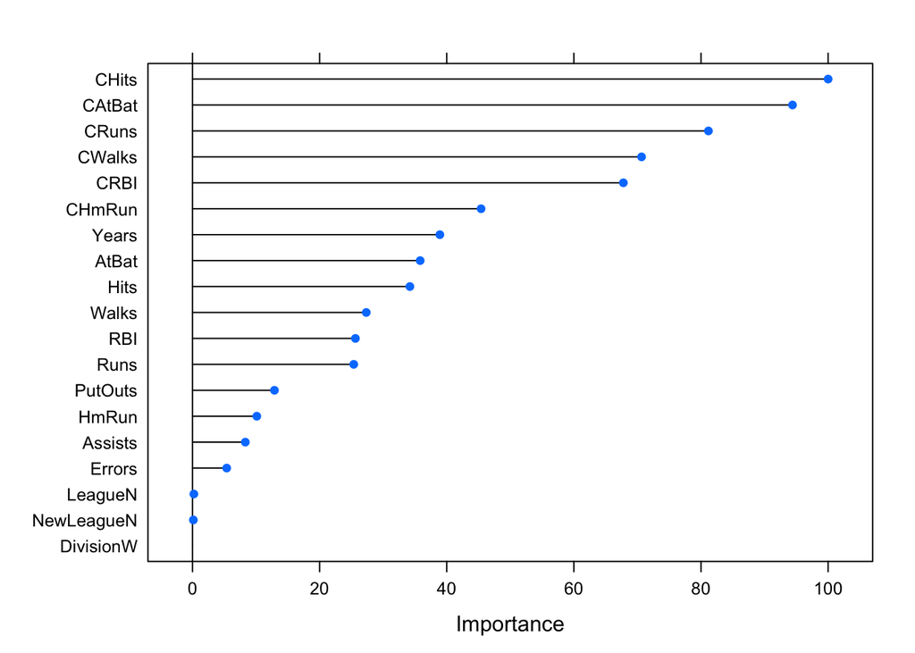

```r
plot(varImp(rf_model))
```

## Gradient boosting machines

Gradient boosting machines: also ensembles of trees, however, the method of choosing them is different. Idea: get the residual and train next tree to predict (explain) the residual. Then add it to the previous trees, with a shrinkage parameter (to avoid overfitting).

Another difference: GBMs use shallow trees (controlled by `interaction.depth`) whereas RFs use unpruned, large trees (with low bias and high variance). Common part: idea of bagging.

```r
gbm_grid <- expand.grid(n.trees = c(100, 500, 1000),
                        interaction.depth = c(2, 3, 5),
                        shrinkage = c(0.005, 0.01, 0.1),
                        n.minobsinnode = c(5))

gbm_model <- train(log_salary ~ .,
                   method = "gbm",
                   data = data_train,
                   trControl = train_control,
                   tuneGrid = gbm_grid,
                   verbose = FALSE # gbm by default prints too much output
                   )
gbm_model
```

```
## Stochastic Gradient Boosting
##
## 200 samples
##  19 predictor
##
## No pre-processing
## Resampling: Cross-Validated (5 fold, repeated 3 times)
## Summary of sample sizes: 161, 160, 158, 161, 160, 158, ...
## Resampling results across tuning parameters:
##
##   shrinkage  interaction.depth  n.trees  RMSE       Rsquared   MAE
##   0.005      2                   100     0.6906629  0.6773637  0.5660394
##   0.005      2                   500     0.5017004  0.7053946  0.3686153
##   0.005      2                  1000     0.4825446  0.7128718  0.3438411
##   0.005      3                   100     0.6791076  0.6941809  0.5573734
##   0.005      3                   500     0.4905865  0.7127320  0.3544624
##   0.005      3                  1000     0.4778216  0.7169544  0.3383697
##   0.005      5                   100     0.6676475  0.7067142  0.5510577
##   0.005      5                   500     0.4825031  0.7172464  0.3460996
##   0.005      5                  1000     0.4760584  0.7183318  0.3368455
##   0.010      2                   100     0.5919384  0.6851806  0.4705229
##   0.010      2                   500     0.4821805  0.7136673  0.3441130
##   0.010      2                  1000     0.4806267  0.7135570  0.3414457
##   0.010      3                   100     0.5743733  0.7012658  0.4561286
##   0.010      3                   500     0.4795826  0.7154064  0.3400952
##   0.010      3                  1000     0.4814251  0.7124513  0.3426803
##   0.010      5                   100     0.5624749  0.7093141  0.4472472
##   0.010      5                   500     0.4758903  0.7189891  0.3360132
##   0.010      5                  1000     0.4812368  0.7125184  0.3437314
##   0.100      2                   100     0.4857297  0.7082035  0.3490345
##   0.100      2                   500     0.5008396  0.6932805  0.3591756
##   0.100      2                  1000     0.5088612  0.6848711  0.3683604
##   0.100      3                   100     0.4919551  0.7006460  0.3534519
##   0.100      3                   500     0.5187675  0.6719210  0.3750518
##   0.100      3                  1000     0.5225798  0.6679292  0.3782517
##   0.100      5                   100     0.4936495  0.7008328  0.3536141
##   0.100      5                   500     0.5063218  0.6855087  0.3652863
##   0.100      5                  1000     0.5073572  0.6842869  0.3661757
##
## Tuning parameter 'n.minobsinnode' was held constant at a value of 5
## RMSE was used to select the optimal model using the smallest value.
## The final values used for the model were n.trees = 500,
##  interaction.depth = 5, shrinkage = 0.01 and n.minobsinnode = 5.
```

```r
# we can refine the grid around the optimum found
gbm_grid_refined <- expand.grid(
  n.trees = c(500, 1000, 2000),
  interaction.depth = c(3, 5, 7),
  shrinkage = c(0.001, 0.005),
  n.minobsinnode = c(5)
)

set.seed(857)
gbm_model_refined <- train(log_salary ~ .,
                   method = "gbm",
                   data = data_train,
                   trControl = train_control,
                   tuneGrid = gbm_grid_refined,
                   verbose = FALSE # gbm by default prints too much output
                   )
gbm_model_refined
```

```
## Stochastic Gradient Boosting
##
## 200 samples
##  19 predictor
##
## No pre-processing
## Resampling: Cross-Validated (5 fold, repeated 3 times)
## Summary of sample sizes: 160, 160, 160, 159, 161, 162, ...
## Resampling results across tuning parameters:
##
##   shrinkage  interaction.depth  n.trees  RMSE       Rsquared   MAE
##   0.001      3                   500     0.6838777  0.6750398  0.5604610
##   0.001      3                  1000     0.5843900  0.6823589  0.4639669
##   0.001      3                  2000     0.5146349  0.6895738  0.3787099
##   0.001      5                   500     0.6749683  0.6842991  0.5554405
##   0.001      5                  1000     0.5730764  0.6893640  0.4546442
##   0.001      5                  2000     0.5059896  0.6945864  0.3673315
##   0.001      7                   500     0.6712533  0.6905635  0.5531598
##   0.001      7                  1000     0.5685670  0.6930776  0.4505175
##   0.001      7                  2000     0.5012278  0.6985375  0.3621183
##   0.005      3                   500     0.5040002  0.6911495  0.3634991
##   0.005      3                  1000     0.4952349  0.6926692  0.3495296
##   0.005      3                  2000     0.5012724  0.6864719  0.3562778
##   0.005      5                   500     0.4967111  0.6968579  0.3541314
##   0.005      5                  1000     0.4923716  0.6965652  0.3486885
##   0.005      5                  2000     0.5017777  0.6868372  0.3584116
##   0.005      7                   500     0.4943491  0.6977588  0.3503403
##   0.005      7                  1000     0.4921573  0.6964722  0.3476320
##   0.005      7                  2000     0.5041818  0.6837878  0.3605518
##
## Tuning parameter 'n.minobsinnode' was held constant at a value of 5
## RMSE was used to select the optimal model using the smallest value.
## The final values used for the model were n.trees = 1000,
##  interaction.depth = 7, shrinkage = 0.005 and n.minobsinnode = 5.
```

Lower `eta` means slower learning, hence more trees are necessary to have good performance.

4 hyperparameters: [the curse of dimensionality](https://en.wikipedia.org/wiki/Curse_of_dimensionality) can make it hard to come up with efficient grids for hyperparameter search. However, with `gbm` and many other models, in reality the models to be estimated are not exponentially growing with the number of hyperparameters (see [here](https://topepo.github.io/caret/random-hyperparameter-search.html)).

The variable importance profile is typically more extreme than for random forests. This is not a contradiction or a problem, just a property of the models and ultimately different faces of the data.

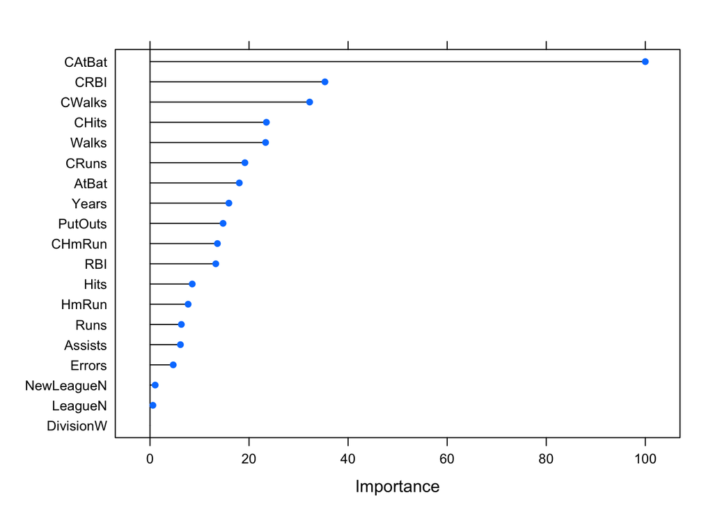

```r
plot(varImp(gbm_model))
```

Not tuned: `bag.fraction` parameter (set to default 0.5): for the construction of each tree, only `bag.fraction` share of the sample is used (randomly selected, see `?gbm`). This, again, is the same idea as with bagging: decrease variance of the model. You can pass another value for it via giving `train` an argument `bag.fraction`, just like we saw with `ranger` and `num.trees`.

```r
gbm_grid_2 <- data.frame(n.trees = c(1000),
                         interaction.depth = c(7),
                         shrinkage = c(0.005),
                         n.minobsinnode = c(5))

set.seed(857)
gbm_model_2 <- train(log_salary ~ .,
                   method = "gbm",
                   data = data_train,
                   trControl = train_control,
                   tuneGrid = gbm_grid_2,
                   bag.fraction = 0.8,
                   verbose = FALSE # gbm by default prints too much output
                   )
gbm_model_2
```

```
## Stochastic Gradient Boosting
##
## 200 samples
##  19 predictor
##
## No pre-processing
## Resampling: Cross-Validated (5 fold, repeated 3 times)
## Summary of sample sizes: 160, 160, 160, 159, 161, 162, ...
## Resampling results:
##
##   RMSE       Rsquared   MAE
##   0.5016504  0.6824947  0.3604717
##
## Tuning parameter 'n.trees' was held constant at a value of 1000
##  7
## Tuning parameter 'shrinkage' was held constant at a value of
##  0.005
## Tuning parameter 'n.minobsinnode' was held constant at a value of 5
```

### XGBoost

A celebrated implementation of the gradient boosting idea. *“Both xgboost and gbm follows the principle of gradient boosting. There are however, the difference in modeling details. Specifically, xgboost used a more regularized model formalization to control over-fitting, which gives it better performance.”*

See documentation [here](http://xgboost.readthedocs.io/). It proved to be very stable and widely applicable. For the many hyperparameters, consult the documentation. New ones compared to prevoiusly seen `gbm`: * `colsample_bytree`: constrain number of columns to use to build a tree in a step

```r
xgb_grid <- expand.grid(nrounds = c(500, 1000),
                       max_depth = c(2, 3, 5),
                       eta = c(0.01, 0.05),
                       gamma = 0,
                       colsample_bytree = c(0.5, 0.7),
                       min_child_weight = 1, # similar to n.minobsinnode
                       subsample = c(0.5))
set.seed(857)
xgboost_model <- train(log_salary ~ .,
                       method = "xgbTree",
                       data = data_train,
                       trControl = train_control,
                       tuneGrid = xgb_grid)
xgboost_model
```

```
## eXtreme Gradient Boosting
##
## 200 samples
##  19 predictor
##
## No pre-processing
## Resampling: Cross-Validated (5 fold, repeated 3 times)
## Summary of sample sizes: 160, 160, 160, 159, 161, 162, ...
## Resampling results across tuning parameters:
##
##   eta   max_depth  colsample_bytree  nrounds  RMSE       Rsquared
##   0.01  2          0.5                500     0.4831526  0.7138636
##   0.01  2          0.5               1000     0.4648092  0.7301256
##   0.01  2          0.7                500     0.4886274  0.7065273
##   0.01  2          0.7               1000     0.4665601  0.7272585
##   0.01  3          0.5                500     0.4842806  0.7122646
##   0.01  3          0.5               1000     0.4610976  0.7344354
##   0.01  3          0.7                500     0.4811193  0.7168133
##   0.01  3          0.7               1000     0.4595849  0.7366733
##   0.01  5          0.5                500     0.4796125  0.7211991
##   0.01  5          0.5               1000     0.4601644  0.7369510
##   0.01  5          0.7                500     0.4862938  0.7141396
##   0.01  5          0.7               1000     0.4661524  0.7310769
##   0.05  2          0.5                500     0.4690905  0.7261727
##   0.05  2          0.5               1000     0.4717254  0.7235511
##   0.05  2          0.7                500     0.4649827  0.7323989
##   0.05  2          0.7               1000     0.4698045  0.7271417
##   0.05  3          0.5                500     0.4683653  0.7253058
##   0.05  3          0.5               1000     0.4717134  0.7218242
##   0.05  3          0.7                500     0.4765051  0.7193493
##   0.05  3          0.7               1000     0.4795403  0.7163455
##   0.05  5          0.5                500     0.4743753  0.7227512
##   0.05  5          0.5               1000     0.4746219  0.7225778
##   0.05  5          0.7                500     0.4747257  0.7245072
##   0.05  5          0.7               1000     0.4749321  0.7242776
##   MAE
##   0.3476360
##   0.3313028
##   0.3498052
##   0.3324473
```

[output cut: 15 more lines]

```
##   0.3451471
##   0.3402433
##   0.3403947
##   0.3463447
##   0.3464857
##
## Tuning parameter 'gamma' was held constant at a value of 0
##
## Tuning parameter 'min_child_weight' was held constant at a value of
##  1
## Tuning parameter 'subsample' was held constant at a value of 0.5
## RMSE was used to select the optimal model using the smallest value.
## The final values used for the model were nrounds = 1000, max_depth =
##  3, eta = 0.01, gamma = 0, colsample_bytree = 0.7, min_child_weight =
##  1 and subsample = 0.5.
```

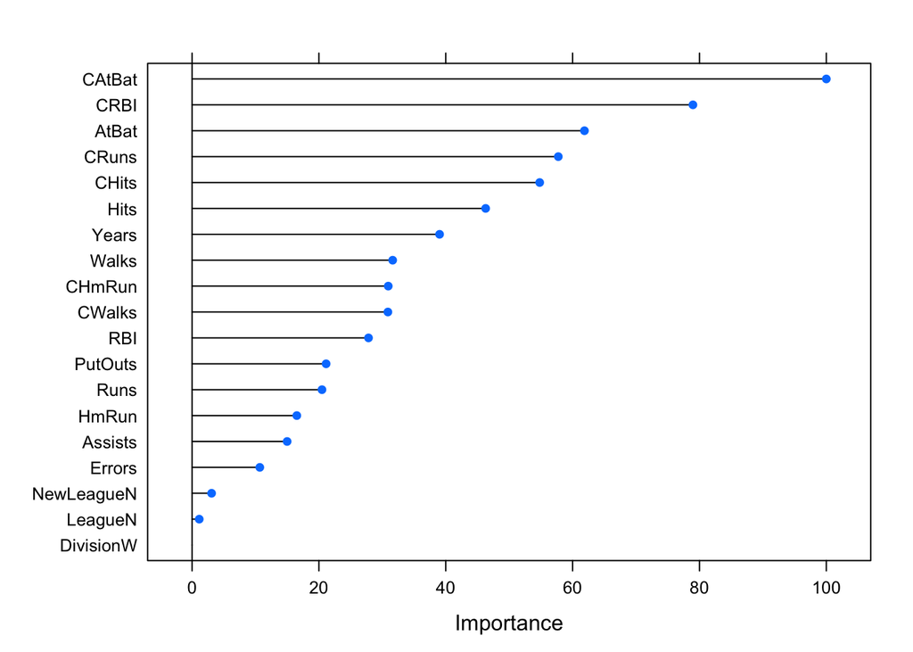

```r
plot(varImp(xgboost_model))
```

```r
resamples_object <- resamples(list("rpart" = simple_tree_model,
                                   "rf" = rf_model,
                                   "gbm" = gbm_model_refined,
                                   "xgboost" = xgboost_model))
summary(resamples_object)
```

```
##
## Call:
## summary.resamples(object = resamples_object)
##
## Models: rpart, rf, gbm, xgboost
## Number of resamples: 15
##
## MAE
##              Min.   1st Qu.    Median      Mean   3rd Qu.      Max. NA's
## rpart   0.3179774 0.3408274 0.4010097 0.4009572 0.4576658 0.5172197    0
## rf      0.2536990 0.3006894 0.3188522 0.3246432 0.3367920 0.4349822    0
## gbm     0.2815472 0.3155988 0.3365911 0.3476320 0.3747285 0.4470339    0
## xgboost 0.2755199 0.2945789 0.3147386 0.3282790 0.3522467 0.4690859    0
##
## RMSE
##              Min.   1st Qu.    Median      Mean   3rd Qu.      Max. NA's
## rpart   0.4019960 0.4321257 0.5071274 0.5387555 0.6183463 0.7516231    0
## rf      0.3339198 0.3962345 0.4249579 0.4541393 0.4896129 0.7377174    0
## gbm     0.3391490 0.4226396 0.4814852 0.4921573 0.5328072 0.7615001    0
## xgboost 0.3380033 0.3935076 0.4311022 0.4595849 0.4765604 0.7821525    0
##
## Rsquared
##              Min.   1st Qu.    Median      Mean   3rd Qu.      Max. NA's
## rpart   0.3977955 0.5204874 0.6835457 0.6405251 0.7539811 0.8284305    0
## rf      0.4721025 0.6822727 0.7475395 0.7433037 0.8470599 0.8987519    0
## gbm     0.4559241 0.6353048 0.7128545 0.6964722 0.7773359 0.8788879    0
## xgboost 0.4381413 0.7018222 0.7465164 0.7366733 0.7986177 0.8763775    0
```